# Neural Network dengan Backpropagation untuk Meramalkan Pertumbuhan Ekspor

## Library dan Data

```r
pacman::p_load(dplyr, ggplot2, lubridate, ggthemes, remotes,
               neuralnet, dummy, Metrics, tidyverse, readxl,
               tictoc, knitr, kableExtra)

# install_github("bearloga/maltese") <- install terlebih dahulu
library(maltese)

# data
# mydata <- read_excel("export data.xlsx")
```

Data time-series (bulanan) tersebut dapat divisualisasikan sebagai berikut:

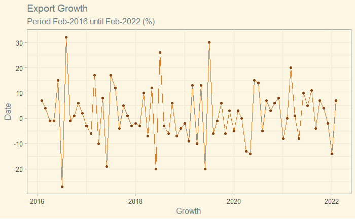

```r
mydata %>%
  ggplot(aes(x = date, y = export_growth)) +
  geom_line(color = "chocolate2") +
  geom_point(color = "chocolate4") +
  theme_solarized() +
  labs(
    title = 'Export Growth',
    subtitle = 'Period Feb-2016 until Feb-2022 (%)') +
  xlab("Growth") + ylab("Date")
```

## Splitting & Preprocessing

Dalam membentuk model NN dengan Backpropagation atau BPNN dan melakukan peramalan, data terlebih dahulu dibagi menjadi training set dan testing set. Splitting point untuk membagi data tersebut misalnya pada bulan Februari 2021.

```r
splitdate <- "2021-03-01"
table(ifelse(mydata$date < splitdate, "training", "testing"))
```

```
 testing training
      12       61
```

Selanjutnya, untuk melakukan BPNN data terlebih dahulu data dinormalisasi.

```r
normal_ <- lapply(
  list(median = median, mad = mad, mean = mean, std.dev = sd),
  do.call,
  args = list(x = mydata$export_growth[mydata$date < splitdate]))

mydata$normalized <- (mydata$export_growth - normal_$mean)/normal_$std.dev
mydata_df <- as.data.frame(mydata)
```

Untuk meramalkan nilai pertumbuhan ekspor ke depannya dengan menggunakan pendekatan NN, diperlukan input variabel. Berbekal data time series yang dimiliki, dilakukan transformasi sehingga menghasilkan beberapa input variabel yang digunakan dalam NN. Proses transformasi ini dilakukan dengan menggunakan bantuan package `maltese`.

Idenya adalah dengan mengekstrak beberapa variabel waktu (e.g. dalam pengamatan ini adalah periode bulan dan jumlah observasi sebelumnya), menjadikannya sebagai *new features*, kemudian mengubahnya dalam bentuk faktor dan mengonversinya dalam bentuk dummy.

```r
# misal digunakan 5 observasi sebelumnya (p = 5)
mlts_data <- mlts_transform(mydata_df, date, normalized,
                            p = 5, extras = T, extrasAsFactors = T,
                            granularity = "month")

mlts_data$mlts_extras_month <- month(mlts_data$dt, label = T)

# convert factor ke dalam bentuk dummy
mlts_cat <- categories(mlts_data[, "mlts_extras_month", drop = FALSE])
mlts_dum <- cbind(mlts_data, dummy(mlts_data[, "mlts_extras_month",
                                        drop = FALSE],
                                   object = mlts_cat, int = TRUE))

str(mlts_dum, list.len = 15)
```

```
'data.frame':   68 obs. of  21 variables:
 $ dt                   : POSIXct, format: "2016-07-01" "2016-08-01" ...
 $ y                    : num  -2.4661 2.6851 -0.1961 -0.0215 0.4151 ...
 $ mlts_extras_month    : Ord.factor w/ 12 levels "Jan"<"Feb"<"Mar"<..: 7 8 9 10 11 12 1 2 3 4 ...
 $ mlts_extras_year     : Ord.factor w/ 7 levels "2016"<"2017"<..: 1 1 1 1 1 1 2 2 2 2 ...
 $ mlts_lag_1           : num  1.2008 -2.4661 2.6851 -0.1961 -0.0215 ...
 $ mlts_lag_2           : num  -0.196 1.201 -2.466 2.685 -0.196 ...
 $ mlts_lag_3           : num  -0.196 -0.196 1.201 -2.466 2.685 ...
 $ mlts_lag_4           : num  0.24 -0.196 -0.196 1.201 -2.466 ...
 $ mlts_lag_5           : num  0.502 0.24 -0.196 -0.196 1.201 ...
 $ mlts_extras_month_Jan: int  0 0 0 0 0 0 1 0 0 0 ...
 $ mlts_extras_month_Feb: int  0 0 0 0 0 0 0 1 0 0 ...
 $ mlts_extras_month_Mar: int  0 0 0 0 0 0 0 0 1 0 ...
 $ mlts_extras_month_Apr: int  0 0 0 0 0 0 0 0 0 1 ...
 $ mlts_extras_month_Mei: int  0 0 0 0 0 0 0 0 0 0 ...
 $ mlts_extras_month_Jun: int  0 0 0 0 0 0 0 0 0 0 ...
  [list output truncated]
```

## Training Model

Selanjutnya kita melatih model dengan berbekal data latih sebanyak 61 pengamatan berdasarkan splitting date.

```r
# training model
training <- which(mlts_dum$dt < splitdate)
testing <- which(mlts_dum$dt >= splitdate)

# membentuk formula
nn_fitur <- grep("(mlts_lag_[0-9])|(mlts_extras_month_.*)",
                 names(mlts_dum), value = TRUE)
nn_form <- as.formula(paste("y ~ ", paste(nn_fitur, collapse = " + ")))
```

Disimulasikan 4 model NN dengan mengkombinasikan jumlah hidden layer dan banyaknya layer, yaitu (1) [5,3]; (2) [7,5,3]; (3) [7,5,5,3]; (4) [7,7,5,3]. Seluruh model menggunakan learning rate sebesar 0.01 dengan fungsi algoritma **Backpropagation**. Dari setiap model akan dievaluasi nilai error dari modelnya **dan** indikator akurasi prediksi yang umum digunakan dalam time series model yaitu root mean squared error (RMSE) serta mean absolute error (MAE). Model yang memberikan error terkecil akan dipilih sebagai model terbaik.

```r
tic()
set.seed(2044)
nn_model1 <- neuralnet(nn_form, mlts_dum[training, c("y", nn_fitur)],
                      linear.output = T, hidden = c(5,3),
                      algorithm = "backprop", learningrate = 0.01,
                      stepmax = 1e7)

nn_model2 <- neuralnet(nn_form, mlts_dum[training, c("y", nn_fitur)],
                       linear.output = T, hidden = c(7,5,3),
                       algorithm = "backprop", learningrate = 0.01,
                       stepmax = 1e7)

nn_model3 <- neuralnet(nn_form, mlts_dum[training, c("y", nn_fitur)],
                       linear.output = T, hidden = c(7,5,5,3),
                       algorithm = "backprop", learningrate = 0.01,
                       stepmax = 1e7)

nn_model4 <- neuralnet(nn_form, mlts_dum[training, c("y", nn_fitur)],
                       linear.output = T, hidden = c(7,7,5,3),
                       algorithm = "backprop", learningrate = 0.01,
                       stepmax = 1e7)
toc()
```

```
1719.28 sec elapsed
```

## Evaluasi Model

Error dari masing-masing model sebagai berikut:

```r
error1 <- nn_model1$result.matrix[1,1]
error2 <- nn_model2$result.matrix[1,1]
error3 <- nn_model3$result.matrix[1,1]
error4 <- nn_model4$result.matrix[1,1]

error_nn <- data.frame(Model = (c("Model 1", "Model 2", "Model 3", "Model 4")),
                       Error = round(c(error1, error2, error3, error4),
                                     digits = 8))

error_nn %>%
  kbl() %>%
  kable_paper(full_width = T) %>%
  column_spec(2, color = "white",
              background = spec_color(1:4, end = 0.4, option = "D", direction = -1),
              popover = paste("am:", error_nn$am[1:4]))
```

| Model | Error |
| --- | --- |
| Model 1 | 0.0936238 |
| Model 2 | 0.0000010 |
| Model 3 | 0.0000009 |
| Model 4 | 0.0000009 |

```r
NA
```

Dilihat dari error, Model 3 dan 4 memiliki nilai terkecil. Langkah selanjutnya adalah membandingkat tingkat ketepatan model dalam meramalkan nilai aktual

```r
# nilai prediksi
nn_pred3 <- as.numeric(compute(nn_model3,
                               mlts_dum[testing, nn_fitur])$net.result)
nn_pred4 <- as.numeric(compute(nn_model4,
                               mlts_dum[testing, nn_fitur])$net.result)

# denormalisasi
prediksi3 <- data.frame(
  date = mlts_dum$dt[testing],
  normalized = nn_pred3,
  denormalized = (nn_pred3 * normal_$std.dev) + normal_$mean)

prediksi4 <- data.frame(
  date = mlts_dum$dt[testing],
  normalized = nn_pred4,
  denormalized = (nn_pred4 * normal_$std.dev) + normal_$mean)
```

Kemudian dapat kita bandingkan plot nya sebagai berikut:

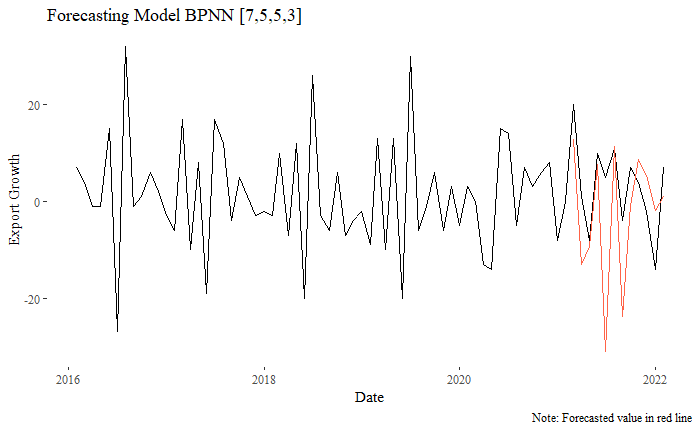

```r
ggplot(mydata_df,
       aes(x = date, y = export_growth)) +
  geom_line() +
  geom_line(aes(y = denormalized), color = "tomato",
            data = prediksi3) +
  theme_tufte() + labs(x = "Date", y = "Export Growth",
       title = "Forecasting Model BPNN [7,5,5,3]",
       caption = "Note: Forecasted value in red line")
```

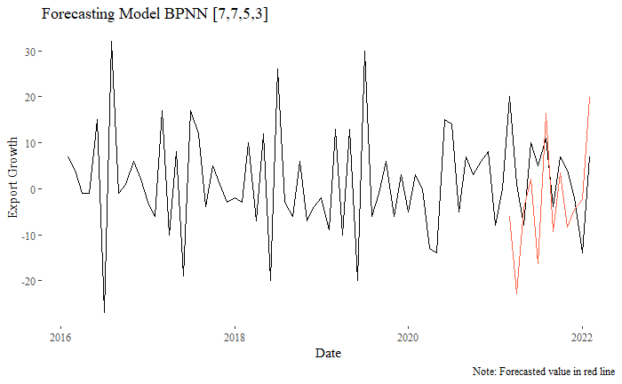

```r
ggplot(mydata_df,
       aes(x = date, y = export_growth)) +
  geom_line() +
  geom_line(aes(y = denormalized), color = "tomato",
            data = prediksi4) +
  theme_tufte() + labs(x = "Date", y = "Export Growth",
       title = "Forecasting Model BPNN [7,7,5,3]",
       caption = "Note: Forecasted value in red line")
```

Setelah plot tersebut, evaluasi atas keakuratan prediksi sebagai berikut:

```r
# evaluasi atas model 3 dan model 4
eval3 <- cbind(mydata_df[62:73,], prediksi3)
eval3 <- eval3[,-c(3:5)]
rmse3 <- rmse(eval3$export_growth, eval3$denormalized)
mae3 <- mae(eval3$export_growth, eval3$denormalized)

eval4 <- cbind(mydata_df[62:73,], prediksi4)
eval4 <- eval4[,-c(3:5)]
rmse4 <- rmse(eval4$export_growth, eval4$denormalized)
mae4 <- mae(eval4$export_growth, eval4$denormalized)

accuracy_nn <- data.frame(ModelNN = (c("Model 3", "Model 4")),
                          RMSE = round(c(rmse3, rmse4), digits = 4),
                          MAE = round(c(mae3, mae4), digits = 4))

accuracy_nn %>%
  kbl() %>%
  kable_paper(full_width = T) %>%
  column_spec(2, color = "white",
              background = spec_color(1:2, end = 0.4,
                                      option = "B", direction = -1),
              popover = paste("am:", accuracy_nn$am[1:2])) %>%
  column_spec(3, color = "white",
              background = spec_color(1:2, end = 0.4,
                                      option = "B", direction = -1),
              popover = paste("am:", accuracy_nn$am[1:2]))
```

| ModelNN | RMSE | MAE |
| --- | --- | --- |
| Model 3 | 13.7652 | 9.9379 |
| Model 4 | 13.8694 | 11.3618 |

Dari perbandingan tersebut dapat dilihat bahwa Model 3 memiliki nilai RMSE dan MAE paling kecil. Dengan demikian Model 3 [7,5,5,3] dipilih sebagai model untuk melakukan peramalan. Model Neural Network yang dibentuk dapat ditampilkan sebagai berikut:

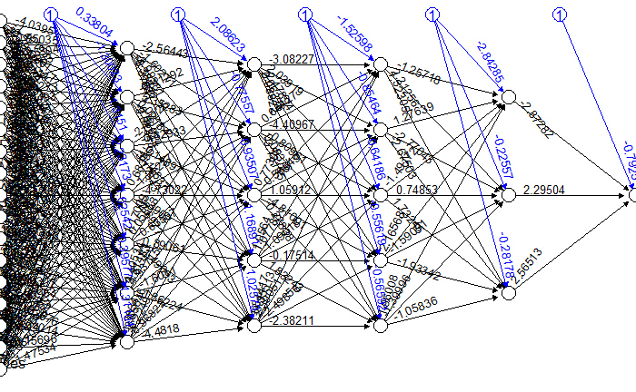

```r
plot(nn_model3, information = T, dimension = 8)
```

## Peramalan

Berdasarkan model BPNN yang dibentuk, misalkan dilakukan peramalan untuk 12 periode waktu ke depan.

```r
options(warn = -4)

mynewdata <- rbind(tail(mydata_df, 22),
                   data.frame(
                     date = seq(as.Date("2022-03-01"),
                                by = "month",
                                length.out = 12),
                     export_growth = NA,
                     normalized = NA
                   )); rownames(mynewdata) <- NULL


for(d in 23:nrow(mynewdata)) {
  newmlts_data <- mlts_transform(
    mynewdata[(d - 22):d, ],
    date, normalized, p = 5,
    extras = T, extrasAsFactors = T,
    granularity = "month")

  newmlts_data$mlts_extras_month <- month(newmlts_data$dt, label = T)

  newmlts_data <- cbind(
    newmlts_data[-1, ],
    dummy(newmlts_data[, "mlts_extras_month",
                       drop = F],
          object = mlts_cat, int = T)[-1, ]
  )
    mynewdata$normalized[d] <- as.numeric(neuralnet::compute(
    nn_model3, newmlts_data[, nn_fitur])$net.result
  )
}

mynewdata$export_growth <- (mynewdata$normalized * normal_$std.dev) +
  normal_$mean
```

Hasil peramalan tersebut apabila diplot sebagai berikut:

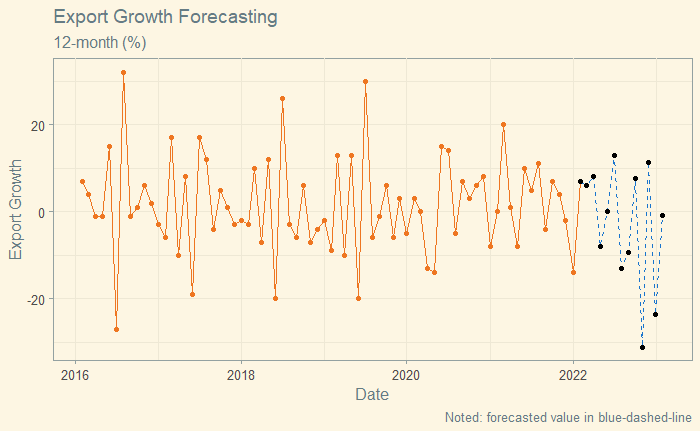

```r
# plot gabungan

ggplot(filter(mydata_df),
       aes(x = date, y = export_growth)) +
  geom_line(color = "chocolate2") + geom_point(color = "chocolate2")+
  geom_line(aes(y = export_growth), color = "dodgerblue3", linetype = 2,
            data = filter(mynewdata, date >= "2022-02-01")) +
  geom_point(data = filter(mynewdata, date >= "2022-02-01")) +
  theme_solarized() +
  labs(x = "Date", y = "Export Growth",
       title = 'Export Growth Forecasting',
         subtitle = "12-month (%)",
       caption = "Noted: forecasted value in blue-dashed-line")
```

Nilai dan plot 12 pengamatan hasil peramalan sebagai berikut:

```r
# data
mynewdata[, 1:2] %>% filter(date > "2022-03-01") %>%
  kbl() %>%
  kable_paper(full_width = T)
```

| date | export_growth |
| --- | --- |
| 2022-03-01 | 5.9981159 |
| 2022-04-01 | 7.9983842 |
| 2022-05-01 | -8.0018894 |
| 2022-06-01 | -0.0020036 |
| 2022-07-01 | 12.8282670 |
| 2022-08-01 | -13.1537937 |
| 2022-09-01 | -9.3656133 |
| 2022-10-01 | 7.6016717 |
| 2022-11-01 | -31.1442150 |
| 2022-12-01 | 11.3499648 |
| 2023-01-01 | -23.7375604 |
| 2023-02-01 | -0.7690747 |

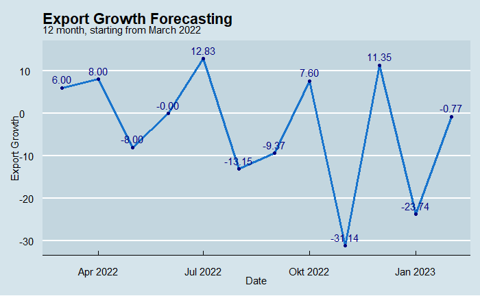

```r
# plot
ggplot(filter(mynewdata, date > "2022-03-01"),
       aes(x = date, y = export_growth,
           label = sprintf("%0.2f", round(export_growth, digits = 2))))+
  geom_line(size = 1.2, color = "dodgerblue3") +
  geom_point(color = "navyblue") +
  geom_text(nudge_y = 2, color = "navyblue") +
  theme_economist(base_family = "helvetica", dkpanel = T) +
  labs(x = "Date", y = "Export Growth",
                           title = "Export Growth Forecasting",
                           subtitle = "12 month, starting from March 2022")
```